# Apprentissage Statistique

Multi-Class classification

04 septembre, 2020

**Abstract**:

The aim of the project is the following : a new company enters the market of mobile phone and want to estimate the the selling price of its mobiles to be fixed.

To estimate this price, we have at our disposal an already prepared data set of 2000 observations which gives the characteristics of the mobile phone (eg:- height, RAM, Internal Memory etc) and its selling price.

But the particular point here is that we are facing a classification problem: instead of a real observed price, we have a price range (from 0 to 3) indicating how high the price is.

So let’s see how we can deal with this kind of problem.

**Data importation**

```r
data_mobile <- read.csv("https://raw.githubusercontent.com/lavergnetse/Data/master/train.csv",
                       sep = ",",  stringsAsFactors = FALSE)

head(data_mobile, 3)
```

```
##   battery_power blue clock_speed dual_sim fc four_g int_memory m_dep mobile_wt
## 1           842    0         2.2        0  1      0          7   0.6       188
## 2          1021    1         0.5        1  0      1         53   0.7       136
## 3           563    1         0.5        1  2      1         41   0.9       145
##   n_cores pc px_height px_width  ram sc_h sc_w talk_time three_g touch_screen
## 1       2  2        20      756 2549    9    7        19       0            0
## 2       3  6       905     1988 2631   17    3         7       1            1
## 3       5  6      1263     1716 2603   11    2         9       1            1
##   wifi price_range
## 1    1           1
## 2    0           2
## 3    0           2
```

Let’s have a first look :

```r
glimpse(data_mobile)
```

```
## Rows: 2,000
## Columns: 21
## $ battery_power <int> 842, 1021, 563, 615, 1821, 1859, 1821, 1954, 1445, 509,…
## $ blue          <int> 0, 1, 1, 1, 1, 0, 0, 0, 1, 1, 1, 1, 0, 1, 0, 0, 0, 0, 1…
## $ clock_speed   <dbl> 2.2, 0.5, 0.5, 2.5, 1.2, 0.5, 1.7, 0.5, 0.5, 0.6, 2.9, …
## $ dual_sim      <int> 0, 1, 1, 0, 0, 1, 0, 1, 0, 1, 1, 0, 0, 0, 0, 0, 0, 1, 1…
## $ fc            <int> 1, 0, 2, 0, 13, 3, 4, 0, 0, 2, 0, 5, 2, 7, 13, 3, 1, 7,…
## $ four_g        <int> 0, 1, 1, 0, 1, 0, 1, 0, 0, 1, 0, 1, 0, 0, 1, 0, 1, 1, 0…
## $ int_memory    <int> 7, 53, 41, 10, 44, 22, 10, 24, 53, 9, 9, 33, 33, 17, 52…
## $ m_dep         <dbl> 0.6, 0.7, 0.9, 0.8, 0.6, 0.7, 0.8, 0.8, 0.7, 0.1, 0.1, …
## $ mobile_wt     <int> 188, 136, 145, 131, 141, 164, 139, 187, 174, 93, 182, 1…
## $ n_cores       <int> 2, 3, 5, 6, 2, 1, 8, 4, 7, 5, 5, 8, 4, 4, 1, 2, 8, 3, 5…
## $ pc            <int> 2, 6, 6, 9, 14, 7, 10, 0, 14, 15, 1, 18, 17, 11, 17, 16…
## $ px_height     <int> 20, 905, 1263, 1216, 1208, 1004, 381, 512, 386, 1137, 2…
## $ px_width      <int> 756, 1988, 1716, 1786, 1212, 1654, 1018, 1149, 836, 122…
## $ ram           <int> 2549, 2631, 2603, 2769, 1411, 1067, 3220, 700, 1099, 51…
## $ sc_h          <int> 9, 17, 11, 16, 8, 17, 13, 16, 17, 19, 5, 14, 18, 7, 14,…
## $ sc_w          <int> 7, 3, 2, 8, 2, 1, 8, 3, 1, 10, 2, 9, 0, 1, 9, 15, 9, 2,…
## $ talk_time     <int> 19, 7, 9, 11, 15, 10, 18, 5, 20, 12, 7, 13, 2, 4, 3, 11…
## $ three_g       <int> 0, 1, 1, 1, 1, 1, 1, 1, 1, 1, 0, 1, 1, 1, 1, 1, 1, 1, 1…
## $ touch_screen  <int> 0, 1, 1, 0, 1, 0, 0, 1, 0, 0, 0, 1, 0, 0, 0, 1, 0, 1, 1…
## $ wifi          <int> 1, 0, 0, 0, 0, 0, 1, 1, 0, 0, 0, 1, 0, 1, 1, 1, 1, 0, 0…
## $ price_range   <int> 1, 2, 2, 2, 1, 1, 3, 0, 0, 0, 3, 3, 1, 2, 0, 0, 3, 3, 1…
```

Our set of feature is the following:

- *battery_power*: Total energy a battery can store in one time measured in mAh
- *blue*: Has bluetooth or not
- *clock_speed*: speed at which microprocessor executes instructions
- *dual_sim*: Has dual sim support or not
- *fc*: Front Camera mega pixels
- *four_g*: Has 4G or not
- *int_memory*: Internal Memory in Gigabytes
- *m_dep*: Mobile Depth in cm
- *mobile_wt*: Weight of mobile phone
- *n_cores*: Number of cores of processor
- *pc*: Primary Camera mega pixels
- *px_height*: Pixel Resolution Height
- *px_width*: Pixel Resolution Width
- *ram*: Random Access Memory in Megabytes
- *sc_h*: Screen Height of mobile in cm
- *sc_w*: Screen Width of mobile in cm
- *talk_time*: longest time that a single battery charge will last when you are
- *three_g*: Has 3G or not
- *touch_screen*: Has touch screen or not
- *wifi*: Has wifi or not

Then regarding the target variable *price_range*:

- 0 (low cost)
- 1 (medium cost)
- 2 (high cost)
- 3 (very high cost)

```r
library(Hmisc)
Hmisc::describe(data_mobile)
```

```
## data_mobile
##
##  21  Variables      2000  Observations
## --------------------------------------------------------------------------------
## battery_power
##        n  missing distinct     Info     Mean      Gmd      .05      .10
##     2000        0     1094        1     1239    507.5    571.0    634.9
##      .25      .50      .75      .90      .95
##    851.8   1226.0   1615.2   1851.0   1930.1
##
## lowest :  501  502  503  504  506, highest: 1994 1995 1996 1997 1998
## --------------------------------------------------------------------------------
## blue
##        n  missing distinct     Info      Sum     Mean      Gmd
##     2000        0        2     0.75      990    0.495   0.5002
##
## --------------------------------------------------------------------------------
## clock_speed
##        n  missing distinct     Info     Mean      Gmd      .05      .10
##     2000        0       26     0.99    1.522   0.9341      0.5      0.5
##      .25      .50      .75      .90      .95
##      0.7      1.5      2.2      2.7      2.8
##
## lowest : 0.5 0.6 0.7 0.8 0.9, highest: 2.6 2.7 2.8 2.9 3.0
## --------------------------------------------------------------------------------
## dual_sim
##        n  missing distinct     Info      Sum     Mean      Gmd
##     2000        0        2     0.75     1019   0.5095   0.5001
##
## --------------------------------------------------------------------------------
## fc
##        n  missing distinct     Info     Mean      Gmd      .05      .10
##     2000        0       20    0.982    4.309    4.693        0        0
##      .25      .50      .75      .90      .95
##        1        3        7       11       13
##
## lowest :  0  1  2  3  4, highest: 15 16 17 18 19
##
## Value          0     1     2     3     4     5     6     7     8     9    10
## Frequency    474   245   189   170   133   139   112   100    77    78    62
```

[output cut: 137 more lines]

```
##
## --------------------------------------------------------------------------------
## wifi
##        n  missing distinct     Info      Sum     Mean      Gmd
##     2000        0        2     0.75     1014    0.507   0.5002
##
## --------------------------------------------------------------------------------
## price_range
##        n  missing distinct     Info     Mean      Gmd
##     2000        0        4    0.938      1.5    1.251
##
## Value         0    1    2    3
## Frequency   500  500  500  500
## Proportion 0.25 0.25 0.25 0.25
## --------------------------------------------------------------------------------
```

Now we will skip the data visualization part and will go directly to the prediction part.

# 1 Model prediction

## 1.1 Dealing with multi-class classification

The famous algorithms we used to use for classic binary classification do not always support classification tasks when there is more than two classes (in particular Logistic Regression and Support Vector Machines). Indeed this specific part of the classification requires other approaches.

### 1.1.1 One-Vs-Rest (OvR)

In a situation where we have n-class, the One-Vs-Rest classification aims to transform the multi-class model into n-binary classifier models. A binary classifier is then trained on each binary classification problem and we combine each of the classifiers’ binary outputs to generate multi-class outputs.

Figure 1: One-vs-Rest illustration

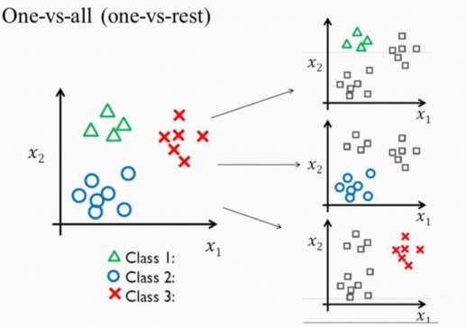

In our example of mobile price, it involves running 4 models:

- Classifier 1: 0 vs [1, 2, 3]
- Classifier 2: 1 vs [0, 2, 3]
- Classifier 3: 2 vs [0, 1, 3]
- Classifier 4: 3 vs [0, 1, 2]

Then you can go with logistic regression or decision three algorithms, to mention just a few.

> As you may guess with a large number of class, this approach may be challenging:

```r
# Create the new classifiers
data_0 = data_mobile
data_1 = data_mobile
data_2 = data_mobile
data_3 = data_mobile

# 1st classifier
data_0 <- data_0 %>% mutate(price_range = if_else(price_range == 0, 1, 0))

# 2nd classifier
data_1 <- data_1 %>% mutate(price_range = if_else(price_range == 1, 1, 0))

# 3rd classifier
data_2 <- data_2 %>% mutate(price_range = if_else(price_range == 2, 1, 0))

# 4th classifier
data_3 <- data_3 %>% mutate(price_range = if_else(price_range == 3, 1, 0))
```

Once the creation of classifiers is complete one can train the model by applying the selected algorithms.

Figure 2: One-vs-Rest representation

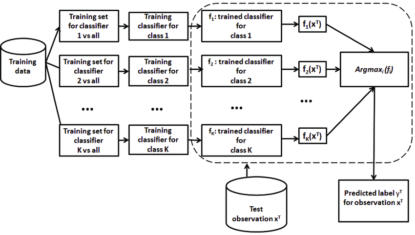

### 1.1.2 One-Vs-One (OvO)

Instead of splitting the the multi-class data set into one binary dataset for each class, the One-Vs-One classification splits it into one binary classification problem per each pair of classes.

Each binary classifier may predict one class label. And then when we input the test data to the classifier, the model with the most predictions or votes is predicted by the OvO strategy.

Figure 3: One-vs-One illustration

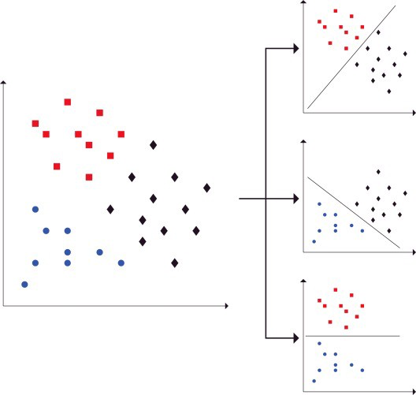

If we have n classes, the formula to compute the number of model to create is the following: $n\times(n-1)/2$

In our example of mobile price, it involves running 6 models:

- Classifier 1: 0 vs 1
- Classifier 2: 0 vs 2
- Classifier 3: 0 vs 3
- Classifier 4: 1 vs 2
- Classifier 5: 1 vs 3
- Classifier 6: 2 vs 3

**Example with r**:

But first let’s split our data into train-set and test-set:

```r
# First we need to transform the output into factor
# Training set:
data_mobile <- data_mobile  %>%
  mutate(price_range = ifelse(price_range == 0, "low",
                       ifelse(price_range == 1, "medium",
                       ifelse(price_range == 2, "high", "very_high"))))

data_mobile$price_range <- as.factor(data_mobile$price_range)

# Data splitting:
set.seed(777)

trainIndex <- createDataPartition(data_mobile$price_range,
                                  p = .75,
                                  list = FALSE,
                                  times = 1)

train_mobile <- data_mobile[trainIndex,]
test_mobile  <- data_mobile[-trainIndex,]
```

```r
library(e1071)
set.seed(777)

svm <- svm(price_range~., data=train_mobile,
          method="C-classification", kernal="linear")

summary(svm)
```

```
##
## Call:
## svm(formula = price_range ~ ., data = train_mobile, method = "C-classification",
##     kernal = "linear")
##
##
## Parameters:
##    SVM-Type:  C-classification
##  SVM-Kernel:  radial
##        cost:  1
##
## Number of Support Vectors:  1225
##
##  ( 367 366 247 245 )
##
##
## Number of Classes:  4
##
## Levels:
##  high low medium very_high
```

Now the Confusion matrix is easy to derive but complex to understand:

```r
# Model performances
svm_prediction <- predict(svm, test_mobile)

svm_confus <-  confusionMatrix(data = svm_prediction, reference = test_mobile$price_range,
                               mode = "everything")
svm_confus
```

```
## Confusion Matrix and Statistics
##
##            Reference
## Prediction  high low medium very_high
##   high       106   0     12         8
##   low          0 118      3         0
##   medium      10   7    110         0
##   very_high    9   0      0       117
##
## Overall Statistics
##
##                Accuracy : 0.902
##                  95% CI : (0.8725, 0.9266)
##     No Information Rate : 0.25
##     P-Value [Acc > NIR] : < 2.2e-16
##
##                   Kappa : 0.8693
##
##  Mcnemar's Test P-Value : NA
##
## Statistics by Class:
##
##                      Class: high Class: low Class: medium Class: very_high
## Sensitivity               0.8480     0.9440        0.8800           0.9360
## Specificity               0.9467     0.9920        0.9547           0.9760
## Pos Pred Value            0.8413     0.9752        0.8661           0.9286
## Neg Pred Value            0.9492     0.9815        0.9598           0.9786
## Precision                 0.8413     0.9752        0.8661           0.9286
## Recall                    0.8480     0.9440        0.8800           0.9360
## F1                        0.8446     0.9593        0.8730           0.9323
## Prevalence                0.2500     0.2500        0.2500           0.2500
## Detection Rate            0.2120     0.2360        0.2200           0.2340
## Detection Prevalence      0.2520     0.2420        0.2540           0.2520
## Balanced Accuracy         0.8973     0.9680        0.9173           0.9560
```

### 1.1.3 Inherently Multi-class Classifiers

If not all models can support multi-class classification, some other can do so. Let’s review them:

1. **K-nn**

First as usual we set up our validation set (especially here, we have to select the option `multiClassSummary` in `the trainControl` function):

```r
# function to set up random seeds
setSeeds <- function(method = "cv", numbers = 1, repeats = 1, tunes = NULL, seed = 1237) {
  #B is the number of resamples and integer vector of M (numbers + tune length if any)
  B <- if (method == "cv") numbers
  else if(method == "repeatedcv") numbers * repeats
  else NULL

  if(is.null(length)) {
    seeds <- NULL
  } else {
    set.seed(seed = seed)
    seeds <- vector(mode = "list", length = B)
    seeds <- lapply(seeds, function(x) sample.int(n = 1000000, size = numbers + ifelse(is.null(tunes), 0, tunes)))
    seeds[[length(seeds) + 1]] <- sample.int(n = 1000000, size = 1)
  }
  # return seeds
  seeds
}


# Seeds
rcvSeeds <- setSeeds(method = "repeatedcv",
                      numbers = 5, repeats = 5,
                      tunes = 100, seed = 777)

# Configure the trainControl argument for cross-validation
CV <- trainControl(method = "repeatedcv", number = 5, repeats = 5,
                      classProbs = TRUE,
                      savePredictions = TRUE,
                      seeds = rcvSeeds,
                      summaryFunction = multiClassSummary)
```

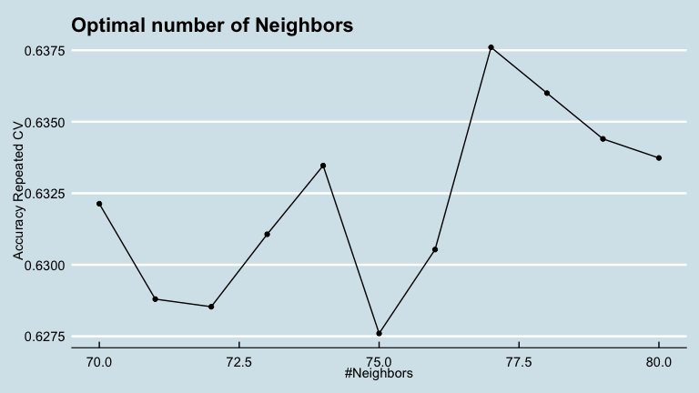

```r
set.seed(777)

# Parameter tuning
# grid <- expand.grid(k = seq (30, 80, 5))
grid <- expand.grid(k = seq (70, 80, 1))

# Model
multi_knn <- train(price_range ~ . ,
                   data = train_mobile,
                   method = "knn",
                   preProcess = c("center","scale"),
                   trControl = CV,
                   tuneGrid = grid)

library(ggthemes)
ggplot(multi_knn) +
  ggtitle("Optimal number of Neighbors") +
  ylab("Accuracy Repeated CV") +
  theme_economist()
```

```r
# Model performances
knn_prediction <- predict(multi_knn, test_mobile)

knn_confus <-  confusionMatrix(data = knn_prediction, reference = test_mobile$price_range,
                               mode = "everything")
knn_confus
```

```
## Confusion Matrix and Statistics
##
##            Reference
## Prediction  high low medium very_high
##   high        85   0     33        34
##   low          0 104     30         0
##   medium      19  21     61         3
##   very_high   21   0      1        88
##
## Overall Statistics
##
##                Accuracy : 0.676
##                  95% CI : (0.633, 0.7169)
##     No Information Rate : 0.25
##     P-Value [Acc > NIR] : < 2.2e-16
##
##                   Kappa : 0.568
##
##  Mcnemar's Test P-Value : NA
##
## Statistics by Class:
##
##                      Class: high Class: low Class: medium Class: very_high
## Sensitivity               0.6800     0.8320        0.4880           0.7040
## Specificity               0.8213     0.9200        0.8853           0.9413
## Pos Pred Value            0.5592     0.7761        0.5865           0.8000
## Neg Pred Value            0.8851     0.9426        0.8384           0.9051
## Precision                 0.5592     0.7761        0.5865           0.8000
## Recall                    0.6800     0.8320        0.4880           0.7040
## F1                        0.6137     0.8031        0.5328           0.7489
## Prevalence                0.2500     0.2500        0.2500           0.2500
## Detection Rate            0.1700     0.2080        0.1220           0.1760
## Detection Prevalence      0.3040     0.2680        0.2080           0.2200
## Balanced Accuracy         0.7507     0.8760        0.6867           0.8227
```

(2) **Shrinkage Discriminant Analysis**

This approach is a modification of the classic linear discriminant analysis and corresponds typically to a multi-class linear discriminant analysis but has a smaller variance.

```r
set.seed(777)
library(sda)

# Model
multi_sda <- train(price_range ~ . ,
                   data = train_mobile,
                   method = "sda",
                   preProcess = c("center", "scale"),
                   trControl = CV)
```

[figure not shown]

```
## Prediction uses 20 features.
```

[output not shown]

(3) **Random Forest**

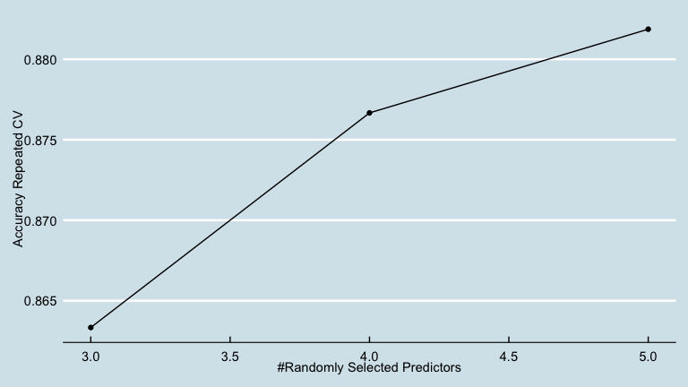

[output not shown]

```r
set.seed(777)

# Parameter tuning
grid <- expand.grid(.mtry = seq (3, 5, 1))

# Model
multi_rf <- train(price_range ~ . ,
                   data = train_mobile,
                   method = "rf",
                   trControl = CV,
                   tuneGrid = grid)

ggplot(multi_rf) +
  ylab("Accuracy Repeated CV") +
  theme_economist()
```

**Model selection**

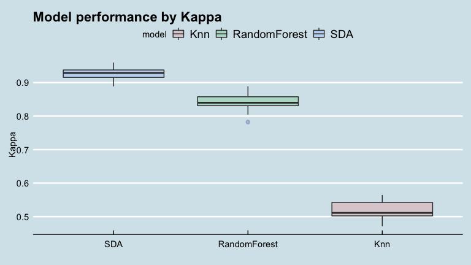

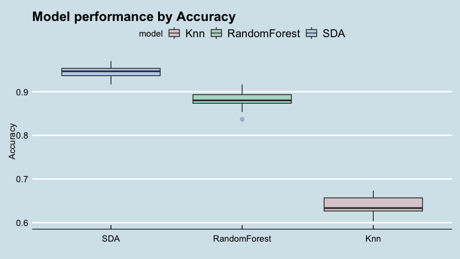

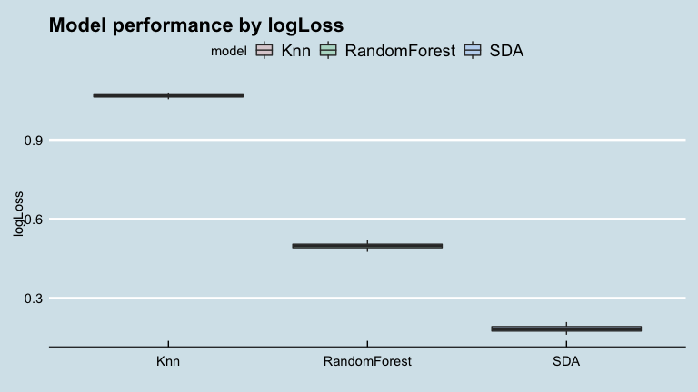

```r
resample_results <- resamples(list(Knn=multi_knn,
                                   SDA=multi_sda,
                                   RandomForest = multi_rf))

models_name <- c("Knn", "SDA", "RandomForest")

df = data.frame()
for (i in models_name){
  metrics = data.frame (model = i,
                  Kappa = resample_results$values[paste(i,"Kappa", sep = "~")],
                  Accuracy = resample_results$values[paste(i,"Accuracy", sep = "~")],
                  logLoss = resample_results$values[paste(i,"logLoss", sep = "~")])
  metrics <- metrics %>% rename(Kappa = paste(i,"Kappa", sep = "."))
  metrics <- metrics %>% rename(Accuracy = paste(i,"Accuracy", sep = "."))
  metrics <- metrics %>% rename(logLoss = paste(i,"logLoss", sep = "."))
  df <- rbind(df,metrics)
}

# So let's plot :
```

> The log-Loss measures the performance of a classification model where the prediction input is a probability value between 0 and 1. This metric increases as the predicted probability diverge from the actual label. Thus a log loss close to 0 is better.

Well, this concludes this quick overview of the different ways to treat multi-class classification problem. Now you can practice and try to find the best prediction score on Kaggle with this already prepared test set:

```r
testing_set <- read.csv("https://raw.githubusercontent.com/lavergnetse/Data/master/test.csv",
                       sep = ",",  stringsAsFactors = FALSE)
```